# Exercise 07

Author

Gianfranco Botta (GianfrancoBotta)

Published

November 7, 2023

## Import libraries

```r
library("affy")
library("UpSetR")
library("limma")
library("knitr")
library("edgeR")
library("ggplot2")
```

## Import data

```r
dir <- "C:/Users/gianf/OneDrive/Documenti/DOCUMENTS_ETH/1 YEAR/1 SEMESTER/SAHTGTD/EXERCISES/affy_estrogen"
targets <- readTargets("targets.txt", path=dir)
targets$time.h <- factor(targets$time.h)
abatch <- ReadAffy(filenames=targets$filename,
                   celfile.path=dir)
eset <- rma(abatch)
```

```
Background correcting
Normalizing
Calculating Expression
```

## Create the contrast matrix as set in exercise 4

```r
# do the limma modeling
f <- paste0(targets$estrogen, targets$time.h)
f <- factor(f)

# create design matrix
design <- model.matrix(~0+f)
colnames(design) <- levels(f)
design
```

```
  absent10 absent48 present10 present48
1        1        0         0         0
2        1        0         0         0
3        0        0         1         0
4        0        0         1         0
5        0        1         0         0
6        0        1         0         0
7        0        0         0         1
8        0        0         0         1
attr(,"assign")
[1] 1 1 1 1
attr(,"contrasts")
attr(,"contrasts")$f
[1] "contr.treatment"
```

```r
fit <- lmFit(eset, design)
```

```r
cont.matrix <- makeContrasts(E10="present10-absent10",
                             E48="present48-absent48",
                             Time="absent48-absent10",levels=design)
cont.matrix
```

```
           Contrasts
Levels      E10 E48 Time
  absent10   -1   0   -1
  absent48    0  -1    1
  present10   1   0    0
  present48   0   1    0
```

```r
fit.c <- contrasts.fit(fit, cont.matrix)
```

## Question 1

*Using the estrogen dataset from Exercise 4, create an UpSet plot summarizing the numbers of differentially expressed genes for the 3 contrasts: ‘E10’, ‘E48’ and ‘Time’ (contrasts as defined in Exercise 4 using makeContrasts()). Hint: you can use decideTests() to summarize the results, given some thresholds. UpSet plots are the new Venn diagrams and can be created with the UpSetR package.*

```r
fit.c <- eBayes(fit.c)
de_genes <- data.frame(decideTests(fit.c, method = "separate", adjust.method = "fdr", p.value = 0.05, lfc = 1))

knitr::kable(de_genes[which(rowMeans(de_genes) != 0)[1:10],])
```

|  | E10 | E48 | Time |
| --- | --- | --- | --- |
| 1005_at | 0 | -1 | 0 |
| 1009_at | 0 | 1 | 0 |
| 1053_at | 1 | 0 | 0 |
| 1055_g_at | 1 | 1 | 0 |
| 1087_at | -1 | -1 | 0 |
| 1126_s_at | 1 | 0 | 0 |
| 1136_at | 0 | 1 | 0 |
| 1158_s_at | 0 | 1 | 0 |
| 1173_g_at | 0 | -1 | 0 |
| 1178_at | 1 | 0 | 0 |

Using the function decideTests we classifies each t-statistic as significantly negative (down-regulation), not significant or significantly positive (up-regulation). If lfc>0 then contrasts are judged significant only when the log2-fold change is at least this large in absolute value. Moreover, we use adjust.method =‘fdr’ (which is equal to ‘BH’) because in microarray studies is more appropriate to control the false discovery rate instead of the family wise error rate, such as the Bonferroni correction. We show a little part of the differential expression results to explain how decideTests works to better understand the following upset plot. For each row, 1 means that that there is evidence that the gene is up-regulated for the considered contrast in the column, -1 means that there is evidence that the gene is down-regulated for the considered contrast, while 0 means there is no particular evidence of differential expression for the considered contrast. Upset plots are very useful to visualize the intersection between more than 3 sets. The total size of each set is represented on the left barplot. Every possible intersection is represented by the bottom plot, and their occurence is shown on the top barplot. Notably, the size of each contrast is calculated by aggregating all values for that specific contrast, which can result in a negative size if down-regulated genes outnumber up-regulated ones in that contrast. To account for both types of differential genes, we divide the negative values by the positive values and subsequently utilize an upset plot to visualize the outcomes.

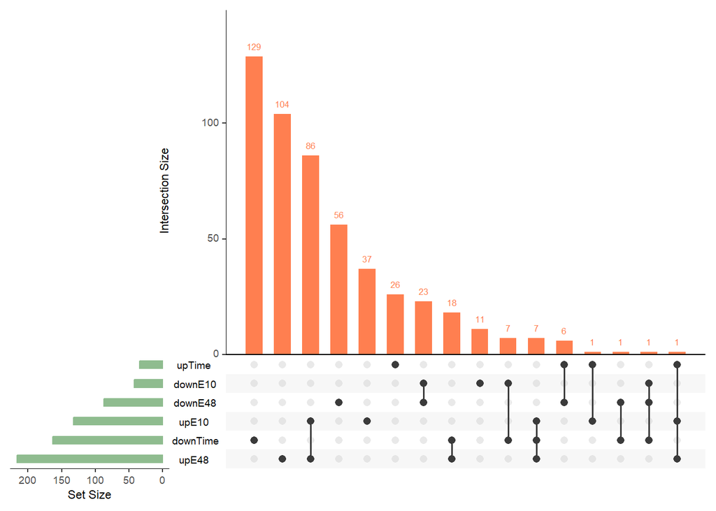

```r
genes_down = de_genes == -1
genes_up = de_genes == 1
colnames(genes_up) <- c(paste0("up", colnames(genes_up)))
colnames(genes_down) <- c(paste0("down", colnames(genes_down)))

mde_genes <- cbind(genes_up, genes_down)

mde_genes[mde_genes] <- 1
mde_genes[!mde_genes] <- 0

mde_genes <- as.data.frame(mde_genes)

UpSetR::upset(mde_genes, sets = colnames(mde_genes), order.by = "freq", main.bar.color = "coral", sets.bar.color = "darkseagreen")
```

## Question 2

*Again using the estrogen dataset from Exercise 4, reproduce the (limma) differential expression analysis using a different design matrix (i.e., a different parameterization; remember, the lectures discussed that differential expression is all about the combination of a design matrix and a contrast matrix). Hint: use the experimental factors defined in the ‘targets’ data frame. Note: trivial changes to the design matrix (e.g., switch the column order) will not be considered as a different design matrix (think: with or without an intercept would be considered a different parameterization, as discussed in the lectures).*

Since the contrasts we want to test are always the same, if we add an intercept in the design matrix, we have to change appropriately the contrast matrix as below.

```r
f_new <- paste0(targets$estrogen, targets$time.h)
f_new <- factor(f_new)

# create design matrix
design_new <- model.matrix(~f_new)
colnames(design_new) <- levels(f_new)
design_new
```

```
  absent10 absent48 present10 present48
1        1        0         0         0
2        1        0         0         0
3        1        0         1         0
4        1        0         1         0
5        1        1         0         0
6        1        1         0         0
7        1        0         0         1
8        1        0         0         1
attr(,"assign")
[1] 0 1 1 1
attr(,"contrasts")
attr(,"contrasts")$f_new
[1] "contr.treatment"
```

```r
fit_new <- lmFit(eset, design_new)

cont.matrix_new <- makeContrasts(E10="present10",
                                 E48="present48-absent48",
                                 Time="absent48",levels=design_new)
cont.matrix_new
```

```
           Contrasts
Levels      E10 E48 Time
  absent10    0   0    0
  absent48    0  -1    1
  present10   1   0    0
  present48   0   1    0
```

```r
fit.c_new <- contrasts.fit(fit_new, cont.matrix_new)

fit.c_new <- eBayes(fit.c_new)
de_genes_new <- data.frame(decideTests(fit.c_new, method = "separate", adjust.method = "fdr", p.value = 0.05, lfc = 1))

knitr::kable(de_genes_new[which(rowMeans(de_genes_new) != 0)[1:10],])
```

|  | E10 | E48 | Time |
| --- | --- | --- | --- |
| 1005_at | 0 | -1 | 0 |
| 1009_at | 0 | 1 | 0 |
| 1053_at | 1 | 0 | 0 |
| 1055_g_at | 1 | 1 | 0 |
| 1087_at | -1 | -1 | 0 |
| 1126_s_at | 1 | 0 | 0 |
| 1136_at | 0 | 1 | 0 |
| 1158_s_at | 0 | 1 | 0 |
| 1173_g_at | 0 | -1 | 0 |
| 1178_at | 1 | 0 | 0 |

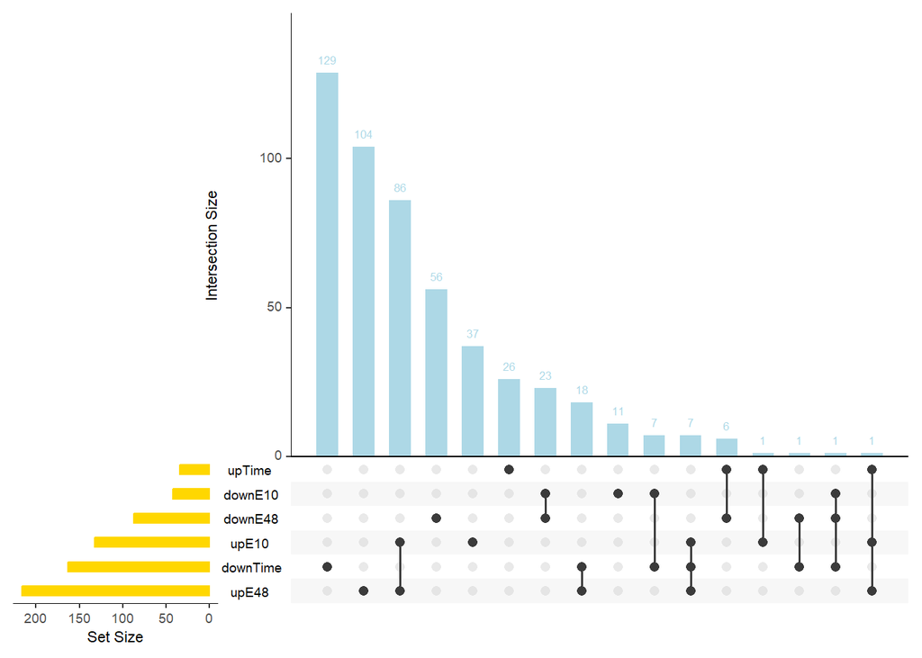

```r
genes_down_new = de_genes_new == -1
genes_up_new = de_genes_new == 1
colnames(genes_up_new) <- c(paste0("up", colnames(genes_up_new)))
colnames(genes_down_new) <- c(paste0("down", colnames(genes_down_new)))

mde_genes_new <- cbind(genes_up_new, genes_down_new)

mde_genes_new[mde_genes_new] <- 1
mde_genes_new[!mde_genes_new] <- 0

mde_genes_new <- as.data.frame(mde_genes_new)
UpSetR::upset(mde_genes_new, sets = colnames(mde_genes_new), order.by = "freq", main.bar.color = "lightblue", sets.bar.color = "gold")
```

We see we obtain the exact same results as before, hence, as long as you can find the right combination of design and contrast matrices to study your contrasts of interest, you can choose any combination.

## Question 3

*Fix the code to work on the count table that was already read in. Add in some spot checks, including an MDS plot from plotMDS() (or similar), a look at the dispersion-mean plot using plotBCV() (or similar) and a look at the overall M vs A plot using plotSmear() (or similar).*

```r
dir_pasilla <- "C:/Users/gianf/OneDrive/Documenti/DOCUMENTS_ETH/1 YEAR/1 SEMESTER/SAHTGTD/EXERCISES/pasilla_data"
setwd(dir_pasilla)
file_path <- paste0(dir_pasilla,"/samples.txt")
samples <- read.table(file_path, header=TRUE,
                      row.names=5, stringsAsFactors=FALSE)
samples
```

```
                  rep condition libtype shortname           countfile
CG8144_RNAi-1.bam  T1         T      SE     T1.SE CG8144_RNAi-1.count
CG8144_RNAi-3.bam  T3         T      PE     T3.PE CG8144_RNAi-3.count
CG8144_RNAi-4.bam  T4         T      PE     T4.PE CG8144_RNAi-4.count
Untreated-1.bam    C1         C      SE     C1.SE   Untreated-1.count
Untreated-6.bam    C6         C      SE     C6.SE   Untreated-6.count
Untreated-3.bam    C3         C      PE     C3.PE   Untreated-3.count
Untreated-4.bam    C4         C      PE     C4.PE   Untreated-4.count
```

```r
counts <- readDGE(samples$countfile)$counts
head(counts)
```

```
             Samples
Tags          CG8144_RNAi-1 CG8144_RNAi-3 CG8144_RNAi-4 Untreated-1 Untreated-6
  FBgn0000008           115            87            68         138          83
  FBgn0000014             0             8             2           1           1
  FBgn0000015             5             2             0           2           0
  FBgn0000017          4579          3074          3313        7152        4099
  FBgn0000018           531           288           307         617         486
  FBgn0000022             0             0             0           1           0
             Samples
Tags          Untreated-3 Untreated-4
  FBgn0000008          75          71
  FBgn0000014           3           4
  FBgn0000015           0           2
  FBgn0000017        3547        3139
  FBgn0000018         240         307
  FBgn0000022           0           0
```

```r
(grp <- gsub("\\-.[0-9]*","",colnames(counts)))
```

```
[1] "CG8144_RNAi" "CG8144_RNAi" "CG8144_RNAi" "Untreated"   "Untreated"
[6] "Untreated"   "Untreated"
```

```r
group <- factor(grp)
y <- DGEList(counts=counts,group=group)
y <- calcNormFactors(y)
design_c <- model.matrix(~group)

y <- estimateDisp(y,design_c)
fit <- glmFit(y,design_c)
lrt <- glmLRT(fit,coef=2)
topTags(lrt)
```

```
Coefficient:  groupUntreated
                logFC   logCPM       LR        PValue           FDR
FBgn0039155  4.612728 5.713330 560.3984 6.885924e-124 1.048451e-119
FBgn0039827  4.026942 4.244841 301.4369  1.602220e-67  1.219770e-63
FBgn0025111 -2.932831 6.716692 292.5665  1.372001e-65  6.963361e-62
FBgn0034736  3.533232 3.987363 222.2421  2.933166e-50  1.116510e-46
FBgn0003360  3.168704 8.269281 219.2281  1.332778e-49  4.058576e-46
FBgn0035085  2.525586 5.429273 206.6463  7.405792e-47  1.879343e-43
FBgn0000071 -2.715199 4.578686 193.1763  6.442282e-44  1.401288e-40
FBgn0029167  2.200346 8.025632 190.2500  2.803829e-43  5.336388e-40
FBgn0029896  2.410059 5.092969 174.8458  6.469506e-40  1.094497e-36
FBgn0034434  3.532031 3.007545 169.2943  1.055100e-38  1.606496e-35
```

Let us explain briefly the process. edgeR stores data in a simple list-based data object called a DGEList. This type of object is easy to use because it can be manipulated like any list in R. The function readDGE makes a DGEList object directly. The main components of an DGEList object are a matrix counts containing the integer counts, a data.frame samples containing information about the samples or libraries, and a optional data.frame genes containing annotation for the genes or genomic features.

Since y is a DGEList object, calcNormFactors(y) returns the relative normalization factors in y$samples$norm.factors. The function estimateDisp calculates a matrix of likelihoods for each gene at a set of dispersion grid points, and then applies weighted likelihood empirical Bayes method to obtain posterior dispersion estimates.

Finally, glmFit fits a negative binomial generalized linear model to add an additional offset. The function glmLRT conducts likelihood ratio tests for one or more coefficients in the linear model. If the argument coef is used, the null hypothesis is that all the coefficients indicated by coef are equal to zero. Since we use coef=2, our H<sub>0</sub> is that all the groupUntreated coefficients are equal to zero. The function topTags extracts the top DE genes (n=10 by default) in a data frame for a given pair of groups (here Treated and Untreated), ranked by p-value (default).

Now, we can insert some spot checks:

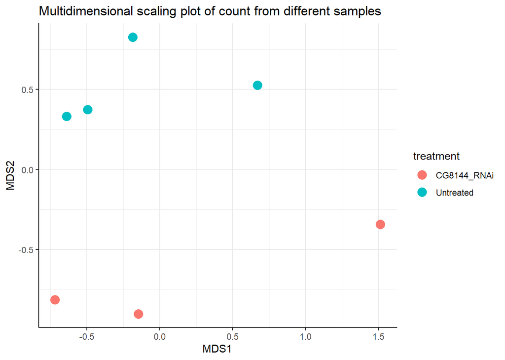

```r
mds <- plotMDS(y, pch = 16, col = as.numeric(group), plot = FALSE)

df <- data.frame(MDS1 = mds$x, MDS2 = mds$y,
                 treatment = y$samples$group)

ggplot(df, aes(x = MDS1, y = MDS2, colour=treatment)) +
  geom_point(size = 4) +
  theme_bw() +
  theme(
    panel.border = element_blank(),
    axis.line = element_line(color = "black", linewidth = 0.5, lineend = "square")
  ) +
  ggtitle("Multidimensional scaling plot of count from different samples")
```

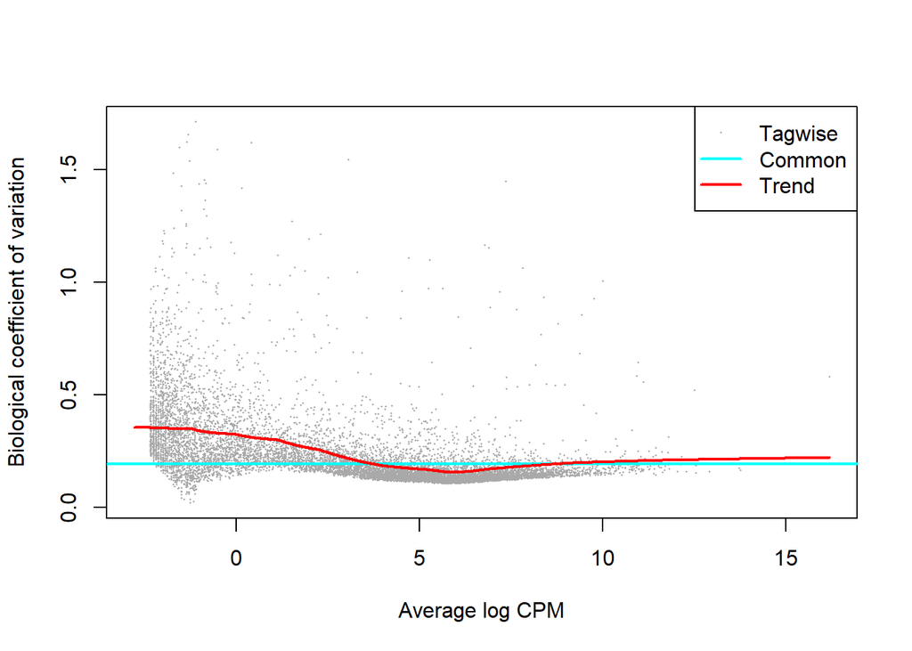

```r
plotBCV(y, col="darkgrey", col.common = "cyan", col.trend = "red")
```

Contrary to the microarray data, in counts data mean and variance are related. Since we use a negative binomial distribution model and we want to estimate the dispersion of each gene, so it is better to share information across genes exploiting the weighted likelihood. Since dispersion varies with mean, we moderate the dispersion towards the trend represented in the BCV plot.

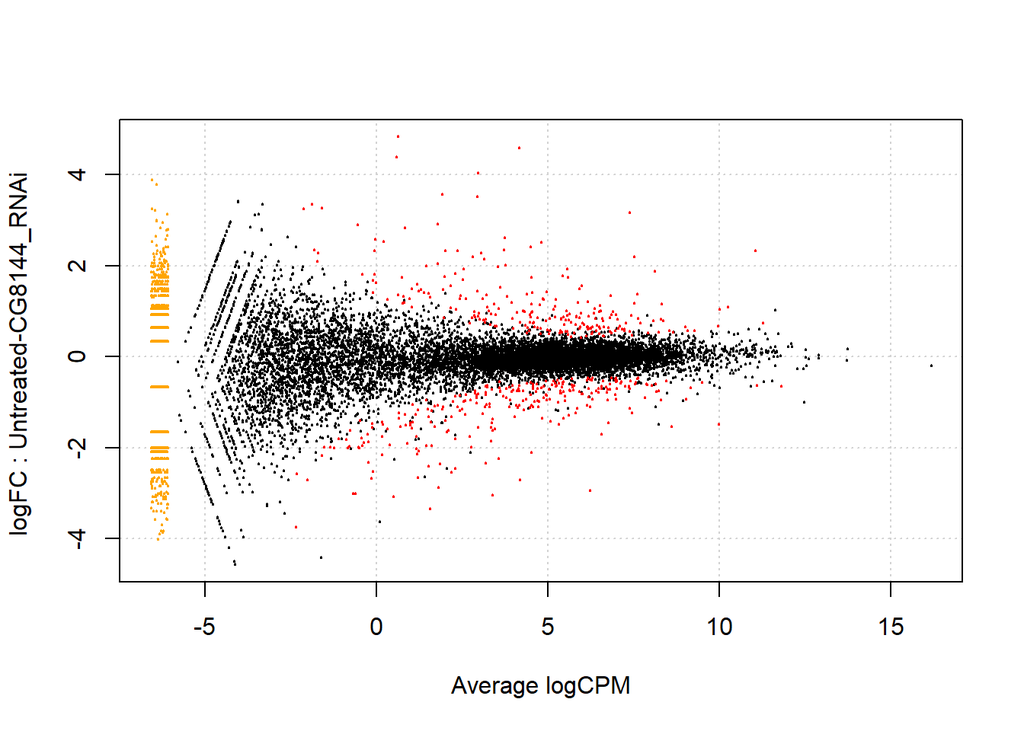

```r
de <- exactTest(y)
top_de_genes <- rownames(topTags(de, n=500)$table)
plotSmear(y, de.tags=top_de_genes)
```

We notice how, using a negative binomial distribution model, the MA plot keeps account for variation even when the average logCPM is big, where the Poisson distribution model would not. The red dots are the most differentially expressed genes.

## Question 4

*For the MDS plot, investigate what happens differently when you call plotMDS() on the DGEList object and when you call it on the normalized counts – for normalized counts, see the cpm() function. Explain why it is different. You may need to read the documentation or even read the code of the plotMDS.DGEList or plotMDS.default functions to understand the difference.*

The different behaviour of plotMDS with a matrix/array and a DGEList relies on the different normalization method. In fact, plotMDS.DGEList converts the counts to log-counts-per-milion using cpm with the argument log=TRUE. After this step, plotMDS.DGEList will pass the log-counts-per-milion to the default function plotMDS. On the contrary, when we call the function cpm(y), the argument log=FALSE by default. Hence, CPM values are not retunred on the log scale when we manually normalize them. Therefore, the different mda coordinates are due to the log transformation, occuring thanks to the argument log=TRUE inside the cpm call only in plotMDS.DGEList.

If we compare the two different normalization on the same MDS plot:

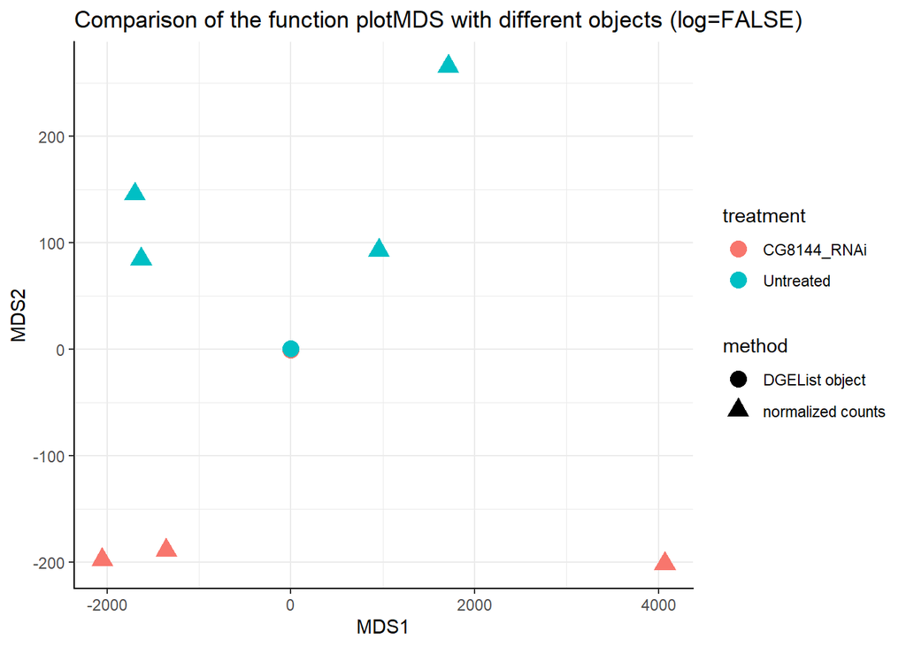

```r
mds <- plotMDS(y, plot = FALSE)
counts_norm = cpm(counts)
mds_norm <- plotMDS(counts_norm, plot = FALSE)

mds_df <- data.frame(MDS1 = mds$x, MDS2 = mds$y,
                 treatment = grp, method = "DGEList object")

mds_df_norm <- data.frame(MDS1 = mds_norm$x, MDS2 = mds_norm$y,
                 treatment = grp, method = "normalized counts")

total_df = rbind(mds_df, mds_df_norm)

ggplot(total_df, aes(x = MDS1, y = MDS2, color = treatment, shape = method)) +
  geom_point(size = 4) +
  theme_bw() +
    theme(
      panel.border = element_blank(),
      axis.line = element_line(color = "black", linewidth = 0.5, lineend = "square")
    ) +
  ggtitle("Comparison of the function plotMDS with different objects (log=FALSE)")
```

we can see that the log-CPM obtained from the DGEList are all very close to each others, because the CPM obtained from the normalized counts are on another scale such that we cannot distinguish the log-CPM. We can have a better visualization of the log-CPM in the MDS plot of point 3.

Finally, we can show that if we insert the argument log=TRUE when manually normalizing the counts, the two results on the MDS plot are comparable:

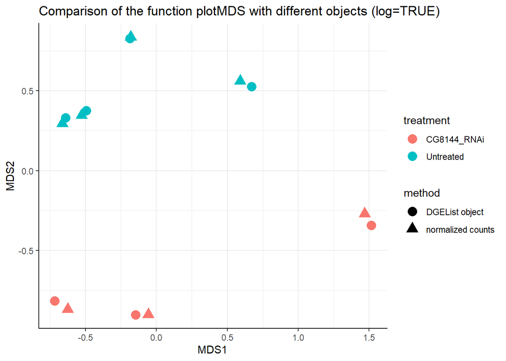

```r
mds <- plotMDS(y, plot = FALSE)
counts_norm = cpm(counts, log=TRUE)
mds_norm <- plotMDS(counts_norm, plot = FALSE)

mds_df <- data.frame(MDS1 = mds$x, MDS2 = mds$y,
                 treatment = grp, method = "DGEList object")

mds_df_norm <- data.frame(MDS1 = mds_norm$x, MDS2 = mds_norm$y,
                 treatment = grp, method = "normalized counts")

total_df = rbind(mds_df, mds_df_norm)

ggplot(total_df, aes(x = MDS1, y = MDS2, color = treatment, shape = method)) +
  geom_point(size = 4) +
  theme_bw() +
    theme(
      panel.border = element_blank(),
      axis.line = element_line(color = "black", linewidth = 0.5, lineend = "square")
    ) +
  ggtitle("Comparison of the function plotMDS with different objects (log=TRUE)")
```

## Question 5

*Again, the above code for voom is not run here. Fix this code to work with the count dataset above and then do some spot checks of the genes called DE. For example, make a plot of the estimated fold changes for the two methods (limma-voom and edgeR), compare the P-values of the two methods, or create a venn diagram of the called sets of DE genes at a set threshold.*

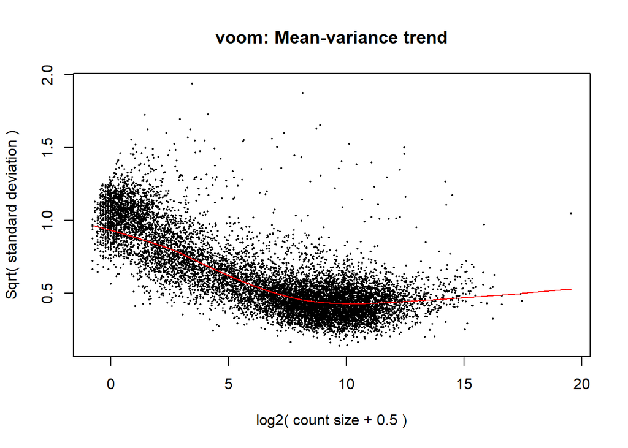

```r
v <- voom(y$counts, design=model.matrix(~grp), plot = TRUE)
```

```r
vf = lmFit(v, design = model.matrix(~grp))  # note similarity to limma
                                            # analysis performed earlier
vf = eBayes(vf)
```

In the voom function, counts are transformed to log2 counts per million reads (CPM), where “per million reads” is defined based on the normalization factors we calculated earlier in the function calcNormFactors. This is done because since we want to use the Limma pipeline, calculating the logCPM flattens a little bit the relation between dispersion and mean in the genes. If this transformation is not enough, one can drop the genes that confer a slope to the curve. The following is just an example:

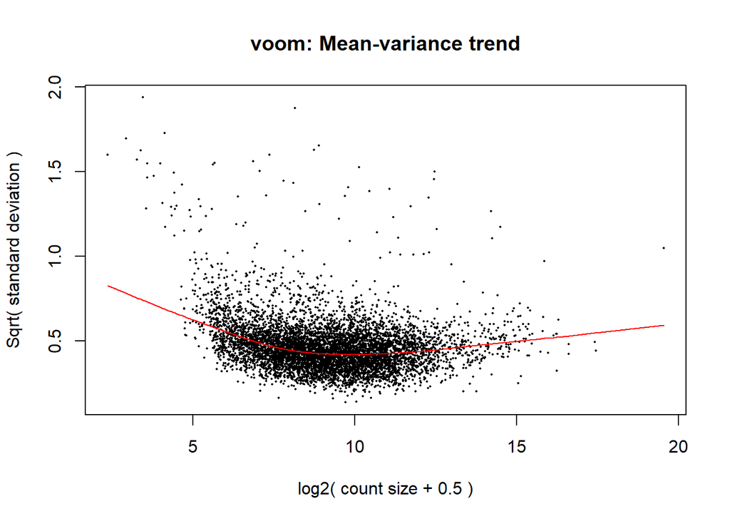

```r
cutoff <- 5
drop <- which(apply(cpm(y), 1, max) < cutoff)
y_drop <- y[-drop,]

v_drop <- voom(y_drop$counts, design=model.matrix(~grp), plot = TRUE)
```

```r
vf_drop = lmFit(v_drop, design = model.matrix(~grp))
vf_drop = eBayes(vf_drop)
```

After having transformed the counts, a linear model is fitted to the log2 CPM for each gene, and the residuals are calculated. Then, a smoothed curve is fitted to the sqrt(residual standard deviation) by average expression (see red line in plot above). Finally, the smoothed curve (which now should be flat enough) is used to obtain weights for each gene and sample that are passed into limma along with the log2 CPMs.